# Demo: Multiple Regression

- Show All Code
- Hide All Code
- View Source

CRISP-DM Phase 4 — Modeling | Carseats Case Study

Author

Prof. Dr. Jörg Schoder

Published

today

**NotePurpose of this document**

This document serves **two functions:**

1. **For the instructor:** Annotated step-by-step guide for the live demo in RStudio. **Instructor note** callouts signal suggested questions, transitions, and emphasis points.
2. **For students:** Complete reference document available after the session.

**Notation (descriptive setting):**

| Symbol | Meaning |
| --- | --- |
| $b_0, b_1, \ldots, b_k$ | OLS coefficients — descriptive, computed from *these* 400 stores |
| $e_i = y_i - \hat{y}_i$ | Residual — calculated from data |
| $\hat{y}_i$ | Fitted value on the regression line / plane |

In PVA2, when we treat the 400 stores as a *sample* from a larger population, notation shifts to $\hat\beta_j$ estimating unknown $\beta_j$, and $e_i$ approximating unobservable $\varepsilon_i$.

**NoteLearning Objectives**

After this session you will be able to:

- **Extend** the baseline equation with a categorical regressor and explain why R converts it into dummy variables automatically
- **Interpret** OLS coefficients as partial derivatives (ceteris paribus) in both the numeric and categorical case
- **Recognise** that `geom_smooth()` with aesthetics `color` implicitly fits an interaction model — and test empirically whether that complexity is warranted
- **Apply** Occam’s Razor via adjusted R²: choose the parallel-slopes model when interaction adds no explanatory power
- **Identify** confounding variables and explain how controlling for them corrects Omitted Variable Bias in the Price coefficient
- **Explain** Simpson’s Paradox: why an aggregate slope can reverse sign when a third variable is controlled for
- **Distinguish** the descriptive purpose of residual diagnostics (misspecification detection) from the inferential purpose (distributional checks, Session 3)

**TipNavigation**

| Symbol | Box colour | Meaning | When to read |
| --- | --- | --- | --- |
|  | **Green — Instructor Note** | Suggested questions, transitions, emphasis points | Before class |
| ⚠️ | **Red — Action Required** | Key concepts, model warnings | During demo |
| ℹ️ | **Blue, open — Note** | Interpretation aids, technical clarifications | As needed |
| 📚 | **Blue, collapsed — Background Theory** | Deeper derivations, optional theory | At home |

**Normal text** and code chunks are the **main content** — work through them in order. **Background sections** are marked with a **collapsed blue box** and can be expanded at any time.

⏱ This demo runs approximately **60 minutes** in the live session.

## 1 Icebreaker: What Does the Baseline Miss?

### 1.1 Where are we in CRISP-DM?

| Phase | Name | Content | Status |
| --- | --- | --- | --- |
| 1 | Business Understanding | Identify underperforming stores | Done (lecture) |
| 2 | Data Understanding | EDA: distributions, correlations, OVB | Done (Lab 1–2) |
| 3 | Data Preparation | ShelveLoc dummy coding, Advertising | Done (Lab 2) |
| 4 | Modelling | Multiple regression: Sales ~ Price + ... | ← This demo |
| 5 | Evaluation | Residuals as performance score, adj. R² | Lab 3 |
| 6 | Deployment | Underperformer ranking, Managerial Memo | Lab 3 |

### 1.2 The residual tells the story

In Lab 2 we estimated the simplest possible model:

$$\widehat{\text{Sales}}_i = b_0 + b_1 \cdot \text{Price}_i$$

```r
tb <- mod_baseline %>%
  get_regression_summaries() %>%
  select(r_squared, adj_r_squared, rmse) %>%
  mutate(Model = "Sales ~ Price") %>%
  relocate(Model) %>%
  gt()
```

**Show code: table formatting**

```r
tb %>%
  fmt_number(columns = c(r_squared, adj_r_squared, rmse), decimals = 3) %>%
  tab_options(table.font.size = "13px") %>%
  tab_header("Baseline — Lab 2")
```

Baseline — Lab 2

| Model | r_squared | adj_r_squared | rmse |
| --- | --- | --- | --- |
| Sales ~ Price | 0.198 | 0.196 | 2.526 |

The residual $e_i = \text{Sales}_i - \hat{y}_i$ is both a **diagnostic** and a **scoring tool:**

- **Diagnostic:** systematic patterns in $e_i$ reveal omitted variables
- **Scoring:** $e_i < 0$ = store sells less than its price-based benchmark → underperformer

```r
gg <- augment(mod_baseline, data = tbl_carseats) %>%
  ggplot(aes(.fitted, .resid, color = ShelveLoc)) +
  geom_point(alpha = 0.45, size = 1.5) +
  geom_hline(yintercept = 0, linetype = "dashed", color = "#333") +
  geom_smooth(aes(group = 1), method = "loess", se = FALSE,
              color = "black", linewidth = 0.9)
```

**Show code: labels & theme**

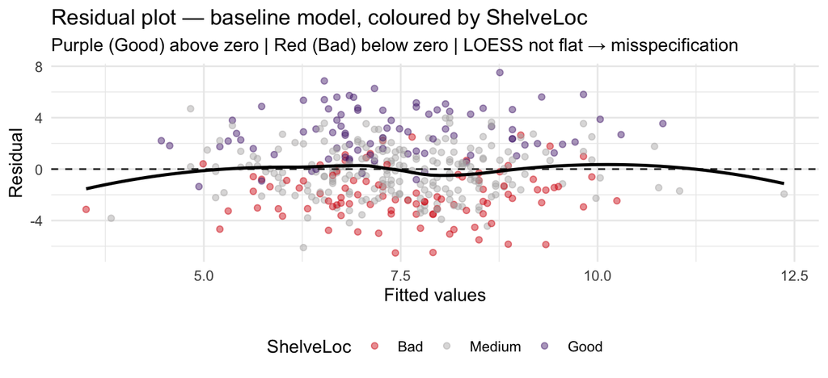

```r
gg +
  scale_color_manual(values = col_shelf_resid) +
  labs(title    = "Residual plot — baseline model, coloured by ShelveLoc",
       subtitle = "Purple (Good) above zero | Red (Bad) below zero | LOESS not flat → misspecification",
       x = "Fitted values", y = "Residual", color = "ShelveLoc") +
  theme_minimal(base_size = 11) +
  theme(legend.position = "bottom")
```

**Tip Instructor note — Icebreaker**

Point to the colour separation: *“Purple dots sit above zero, red dots below — systematically. `ShelveLoc` explains part of the residual that our model ignores. The obvious fix: add `ShelveLoc` to the equation.”*

## 2 The General Model

For $k$ regressors, the regression model (descriptive model notation) is:

$$y_i = b_0 + b_1 x_{i1} + b_2 x_{i2} + \dots + b_k x_{ik} + e_i$$

OLS minimises $\sum_{i=1}^n e_i^2$. Because the model is linear, each coefficient is the partial derivative of the fitted surface — the slope in one direction while all others are held fixed:

$$b_j = \frac{\partial \hat{y}}{\partial x_j}
\quad \text{(ceteris paribus)}$$

This is a **mathematical** statement about the slope of the fitted surface. It is **not** a causal claim.

### 2.1 What combinations of regressors will we see?

Multiple regression handles regressors of different scale levels — the combination determines both the geometry and the interpretation. This demo works through two cases in order of increasing insight, then points to what happens with more than two regressors.

Regressor combinations covered in this demo

Case A first — ShelveLoc explains nearly twice as much variance as Advertising

| Case | Regressors | Geometry | This demo |
| --- | --- | --- | --- |
| Baseline | 1 numeric (Price) | Line in 2D | Lab 2 — starting point |
| Case A | 1 numeric + 1 categorical (Price + ShelveLoc) | Parallel lines in 2D (one per group) | ← Section 3 |
| Case B | 2 numeric (Price + Advertising) | Plane in 3D | ← Section 4 |
| Full model | 2 numeric + 1 categorical (Price + Adv + ShelveLoc) | Parallel planes in 3D | ← Section 5 |
| General k>2 | k regressors (any mix) | Hyperplane — not visualisable | Same algebra, PVA2 |

**NoteWhy Case A before Case B?**

A quick empirical check before we start:

- `Sales ~ Price + ShelveLoc` → adj. R² ≈ **0.54**
- `Sales ~ Price + Advertising` → adj. R² ≈ **0.28**

The categorical variable `ShelveLoc` explains almost twice as much variance as the numeric variable `Advertising`. The modelling sequence follows the data — not textbook convention.

**CautionBackground: Matrix notation (optional)**

For $n$ observations and $k$ regressors (including an intercept column of ones):

$$\mathbf{y} = \mathbf{X}\,\mathbf{b} + \mathbf{e}$$

OLS solution: $\mathbf{b} = (\mathbf{X}'\mathbf{X})^{-1}\mathbf{X}'\mathbf{y}$ (requires $\mathbf{X}'\mathbf{X}$ invertible — no perfect multicollinearity). Each element of $\mathbf{b}$ is the same partial derivative as above; the matrix form makes computation tractable for arbitrary $k$.

## 3 Case A: What if We Just Add `ShelveLoc`?

This section covers **Case A** from the overview table: one numeric regressor (`Price`) and one categorical regressor (`ShelveLoc`). This is the most common starting point in applied regression — one continuous measure of interest, one grouping variable that needs to be controlled for. The key challenge: a categorical variable cannot enter a regression equation as-is. It must first be converted into a numeric representation.

### 3.1 The model equation — written out

The residual plot showed that `ShelveLoc` is the missing piece. Adding it extends the baseline equation to:

$$\widehat{\text{Sales}}_i = b_0 + b_1 \cdot \text{Price}_i + b_2 \cdot \text{ShelveLoc}_i \tag{1}$$

But wait — `ShelveLoc` is not a number. As we have seen in **Lab 2**, `ShelveLoc` is a **factor** variable with three ordered levels ($k = 3$): Bad → Medium → Good. Since a category cannot be multiplied with a coefficient, automatically converts factor objects into so called **dummy variables**: one binary indicator per category, minus one for the reference group. Hence, in our case ($k = 3$) creates $k - 1 = 2$ dummies for `ShelveLoc`:

**CautionBackground: Dummy variables — binary, dichotomous, indicator**

A **dummy variable** (also called **binary**, **dichotomous**, or **indicator** variable) takes only two values:

| Value | Meaning |
| --- | --- |
| `1` | The observation belongs to this category |
| `0` | It does not |

For `ShelveLoc` with $k = 3$ categories, R creates $k - 1 = 2$ dummies:

| Store | ShelveLocMedium | ShelveLocGood |
| --- | --- | --- |
| Bad shelf | 0 | 0 |
| Medium shelf | 1 | 0 |
| Good shelf | 0 | 1 |

**Why $k - 1$ and not $k$?** If all three dummies were included, their columns would always sum to 1 — a perfect linear combination of the intercept column. The design matrix $\mathbf{X}$ would be singular ($\mathbf{X}'\mathbf{X}$ not invertible) and OLS would have no unique solution. Dropping one category — the **reference group** (`Bad`) — resolves this. Its effect is absorbed into the intercept $b_0$.

**Synonyms in the literature:**

| Term | Common in |
| --- | --- |
| Dummy variable | Econometrics (Wooldridge, Greene) |
| Indicator variable | Statistics, R documentation |
| Binary variable | Machine learning |
| Dichotomous variable | Psychology, survey research |
| One-hot encoding | Machine learning (all $k$ dummies, no intercept) |

| ShelveLoc | Absorbed into | ShelveLocGood | ShelveLocMedium |
| --- | --- | --- | --- |
| Bad (reference) | b₀ (intercept) | 0 | 0 |
| Medium | — | 0 | 1 |
| Good | — | 1 | 0 |

Reference = Bad (first level — set explicitly in setup). Change with relevel(ShelveLoc, ref = 'Good') if needed.

The full equation with dummies therefore replaces the placeholder $b_2 \cdot \text{ShelveLoc}_i$ from equation (1) with two explicit dummy terms:

$$\widehat{\text{Sales}}_i = b_0 + b_1 \cdot \text{Price}_i
+ b_2 \cdot \mathbf{1}_{\text{Good},\,i}
+ b_3 \cdot \mathbf{1}_{\text{Medium},\,i} \tag{2}$$

Each `ShelveLoc` group gets its own **intercept shift** ($b_2$ or $b_3$) but the **same Price slope** ($b_1$) — that is the **parallel slopes** assumption.

**NoteFrom equation to `lm()` — the direct mapping**

| Equation (2) term | R formula term |
| --- | --- |
| $b_0$ (intercept) | always included by default |
| $b_1 \cdot \text{Price}_i$ | `Price` |
| $b_2 \cdot \mathbf{1}_{\text{Good}}$ | automatically from `ShelveLoc` |
| $b_3 \cdot \mathbf{1}_{\text{Medium}}$ | automatically from `ShelveLoc` |
| **Additive (`+`): same slope** | `lm(Sales ~ Price + ShelveLoc)` |
| **Interaction (`*`): different slopes** | `lm(Sales ~ Price * ShelveLoc)` |

The `+` operator means: same slope for all groups (additive / parallel slopes). The `*` operator means: different slope per group (interaction term included).

### 3.2 Step 1 — `lm(Sales ~ Price + ShelveLoc)`: fit and inspect

Following equation (2), we translate directly into R:

```r
mod_shelf <- lm(Sales ~ Price + ShelveLoc, data = tbl_carseats)

tb <- mod_shelf %>%
  get_regression_table() %>%
  select(term, estimate) %>%
  gt()
```

**Show code: table formatting**

```r
tb %>%
  fmt_number(columns = estimate, decimals = 4) %>%
  tab_style(style = cell_fill(color = "#f5f0fa"),
            locations = cells_body(rows = str_detect(term, "ShelveLoc"))) %>%
  tab_style(style = cell_fill(color = "#fff0f0"),
            locations = cells_body(rows = term == "Price")) %>%
  tab_options(table.font.size = "13px") %>%
  tab_header(
    paste0("Sales ~ Price + ShelveLoc  |  adj. R² = ",
           round(summary(mod_shelf)$adj.r.squared, 3)),
    subtitle = "Same Price slope (b₁) for all three groups — parallel slopes by construction"
  )
```

Sales ~ Price + ShelveLoc | adj. R² = 0.539

Same Price slope (b₁) for all three groups — parallel slopes by construction

| term | estimate |
| --- | --- |
| intercept | 12.0020 |
| Price | −0.0570 |
| ShelveLoc: Medium | 1.8620 |
| ShelveLoc: Good | 4.8960 |

**CautionBackground: Reading the parallel slopes table**

The table has four rows, corresponding directly to equation (2):

- **`(Intercept)`** = $b_0$ — predicted Sales for a **Bad**-shelf store at Price = 0 (not meaningful; see centering later)
- **`Price`** = $b_1$ — the Price effect, **identical for all three shelf groups**
- **`ShelveLocGood`** = $b_2$ — how much higher Good-shelf stores sell compared to Bad, at any given Price
- **`ShelveLocMedium`** = $b_3$ — same logic for Medium vs. Bad

The key constraint: there is **one single Price slope** $b_1$. This is the parallel-slopes assumption — all three lines tilt at the same angle.

**NoteIn descriptive regression we focus on the `estimate` column only**

The full `get_regression_table()` output also shows `std_error`, `statistic`, `p_value`, `lower_ci`, and `upper_ci`. These are **inferential** quantities — meaningful only when treating the 400 stores as a *sample* from a larger population.

In the **descriptive** setting, all 400 stores *are* the population. Standard errors and p-values are not defined for a population — and the term **`estimate`** is itself slightly misleading here: there is nothing to estimate when you have the full population. The coefficients $b_0, b_1, \ldots$ are exact descriptive summaries, not estimates.

We return to these inferential statistics in Session 3.

### 3.3 Step 2 — Visualise: `geom_smooth()` vs. what our model implies

Our model (equation 2) implies parallel lines — same slope, different intercepts. Let’s plot it, then compare with the `geom_smooth()` picture from earlier:

**Show code: parallel slopes plot**

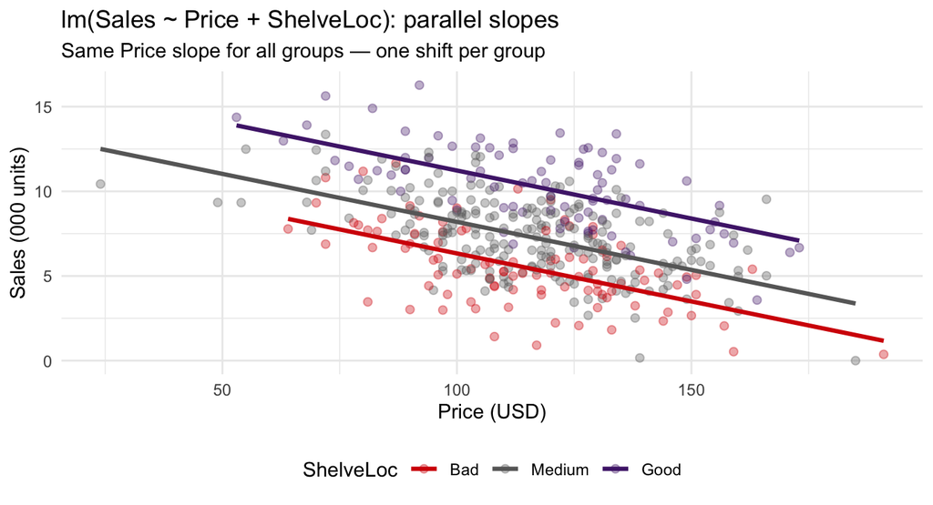

```r
tbl_carseats %>%
  ggplot(aes(x = Price, y = Sales, color = ShelveLoc)) +
  geom_point(alpha = 0.35, size = 1.8) +
  geom_parallel_slopes(se = FALSE, linewidth = 1.1) +
  scale_color_manual(values = col_shelf) +
  labs(title    = "lm(Sales ~ Price + ShelveLoc): parallel slopes",
       subtitle = "Same Price slope for all groups — one shift per group",
       x = "Price (USD)", y = "Sales (000 units)", color = "ShelveLoc") +
  theme_minimal(base_size = 11) +
  theme(legend.position = "bottom")
```

Now compare with what `geom_smooth()` produced when we visualised earlier:

**Show code: geom_smooth() plot**

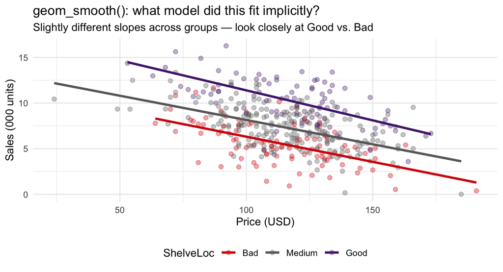

```r
tbl_carseats %>%
  ggplot(aes(x = Price, y = Sales, color = ShelveLoc)) +
  geom_point(alpha = 0.35, size = 1.8) +
  geom_smooth(method = "lm", se = FALSE, linewidth = 1.1) +
  scale_color_manual(values = col_shelf) +
  labs(title    = "geom_smooth(): what model did this fit implicitly?",
       subtitle = "Slightly different slopes across groups — look closely at Good vs. Bad",
       x = "Price (USD)", y = "Sales (000 units)", color = "ShelveLoc") +
  theme_minimal(base_size = 11) +
  theme(legend.position = "bottom")
```

Looking at the `geom_smooth()` plot, the three lines appear nearly — but not perfectly — parallel. A **close inspection** reveals **slightly different slopes** across shelf locations: the price sensitivity seems marginally stronger for `Good` stores than for `Bad` ones. But should we trust this visual impression, or is it an artefact of fitting separate lines to noisy data?

**Important`geom_smooth()` implicitly fits the interaction model**

When aesthetics `color` maps to a categorical variable, ggplot2 fits **separate lines per group** — each with its own intercept *and* slope. This corresponds to a different equation:

$$\widehat{\text{Sales}}_i = b_0 + b_1 \cdot \text{Price}_i
+ b_2 \cdot \mathbf{1}_{\text{Good}}
+ b_3 \cdot \mathbf{1}_{\text{Medium}}
+ b_4 \cdot (\text{Price}_i \times \mathbf{1}_{\text{Good}})
+ b_5 \cdot (\text{Price}_i \times \mathbf{1}_{\text{Medium}}) \tag{3}$$

i.e. `lm(Sales ~ Price * ShelveLoc)` — **not** `lm(Sales ~ Price + ShelveLoc)`.

**CautionBackground: `geom_parallel_slopes()` — why it is not in base ggplot2**

`geom_parallel_slopes()` is a function from the **moderndive** package — it is not available in base ggplot2.

ggplot2’s `geom_smooth(method = "lm")` always fits the most general model within each colour group — the interaction model (separate intercept *and* slope). There is no built-in option to force equal slopes across groups. `geom_parallel_slopes()` fills this gap: it fits `lm(y ~ x + group)` internally and plots the resulting parallel lines.

**The practical rule:** whenever you use `geom_smooth()` with a categorical colour aesthetic, you are visualising an interaction model — whether you intend to or not.

### 3.4 Step 3 — `lm(Sales ~ Price * ShelveLoc)`: resolve the contradiction

`geom_smooth()` fitted equation (3) — the interaction model. The interaction terms $b_4$ and $b_5$ capture whether the **effect of Price on Sales differs depending on shelf location**. In other words: does a price increase hurt sales more for a prominently placed product than for one tucked away on a bad shelf? If so, Price and ShelveLoc *interact* — and the slopes would differ across groups.

```r
mod_int_shelf <- lm(Sales ~ Price * ShelveLoc, data = tbl_carseats)

tb <- mod_int_shelf %>%
  get_regression_table() %>%
  select(term, estimate) %>%
  gt()
```

**Show code: table formatting**

```r
tb %>%
  fmt_number(columns = estimate, decimals = 4) %>%
  tab_style(style = cell_fill(color = "#f5f0fa"),
            locations = cells_body(rows = str_detect(term, "ShelveLoc") &
                                     !str_detect(term, ":"))) %>%
  tab_style(style = cell_fill(color = "#fff8e1"),
            locations = cells_body(rows = str_detect(term, ":"))) %>%
  tab_options(table.font.size = "13px") %>%
  tab_header(
    paste0("Sales ~ Price × ShelveLoc  |  adj. R² = ",
           round(summary(mod_int_shelf)$adj.r.squared, 3)),
    subtitle = "Purple = ShelveLoc intercept shifts  |  Yellow = slope offsets (interaction terms, eq. 3)"
  )
```

Sales ~ Price × ShelveLoc | adj. R² = 0.539

Purple = ShelveLoc intercept shifts | Yellow = slope offsets (interaction terms, eq. 3)

| term | estimate |
| --- | --- |
| intercept | 11.8330 |
| Price | −0.0550 |
| ShelveLoc: Medium | 1.6300 |
| ShelveLoc: Good | 6.1360 |
| Price:ShelveLocMedium | 0.0020 |
| Price:ShelveLocGood | −0.0110 |

**CautionBackground: Reading the interaction table**

The table has **six rows** — two more than equation (2). The yellow rows are the interaction terms: slope offsets relative to Bad.

**Reconstruct each group’s line from the table:**

| ShelveLoc group | Intercept | Price slope | How computed |
| --- | --- | --- | --- |
| Bad (reference) | 11.833 | -0.0552 | b₀ / b₁ |
| Good | 17.969 | -0.0658 | (b₀ + b_Good) / (b₁ + b_{Price:Good}) |
| Medium | 13.463 | -0.0532 | (b₀ + b_Medium) / (b₁ + b_{Price:Medium}) |

Bad is the reference group — its values appear directly in b₀ and b₁

**Tip Instructor note — interaction tables**

*“The table has 6 rows. None gives you the intercept or slope for Good or Medium directly — you always add the offset to the reference-group value.”*

### 3.5 Occam’s Razor: the simpler model wins

```r
tb <- bind_rows(
  get_regression_summaries(mod_shelf) %>%
    mutate(Model = "Parallel slopes: Sales ~ Price + ShelveLoc", k = 4),
  get_regression_summaries(mod_int_shelf) %>%
    mutate(Model = "Interaction:     Sales ~ Price × ShelveLoc", k = 6)
) %>%
  select(Model, k, r_squared, adj_r_squared, rmse) %>%
  gt()
```

**Show code: table formatting**

```r
tb %>%
  fmt_number(columns = c(r_squared, adj_r_squared, rmse), decimals = 4) %>%
  tab_style(style = cell_fill(color = "#f0fff0"),
            locations = cells_body(rows = 1)) %>%
  tab_options(table.font.size = "13px") %>%
  tab_header(
    "Parallel slopes vs. interaction: adj. R² is the referee",
    subtitle = "adj. R² penalises the 2 extra parameters of the interaction model"
  )
```

Parallel slopes vs. interaction: adj. R² is the referee

adj. R² penalises the 2 extra parameters of the interaction model

| Model | k | r_squared | adj_r_squared | rmse |
| --- | --- | --- | --- | --- |
| Parallel slopes: Sales ~ Price + ShelveLoc | 4 | 0.5430 | 0.5390 | 1.9076 |
| Interaction: Sales ~ Price × ShelveLoc | 6 | 0.5440 | 0.5390 | 1.9038 |

**NoteOccam’s Razor: prefer the simpler model when fit is equal**

> *“Under otherwise equal conditions, simpler models are preferable to complex ones.”*

adj. R² is **identical at 0.539** for both models (equations 2 and 3), yet the interaction model uses 2 extra parameters. Zero marginal benefit → equation (2), the parallel slopes model, wins.

The near-parallel lines in `geom_smooth()` were not misleading — they reflected a genuine data property: the Price sensitivity is the same across shelf locations.

See the background box below for a counter-example where interaction *is* warranted and adj. R² confirms it.

### 3.6 Eyeball test: with vs. without interaction term

**Show code: side-by-side comparison**

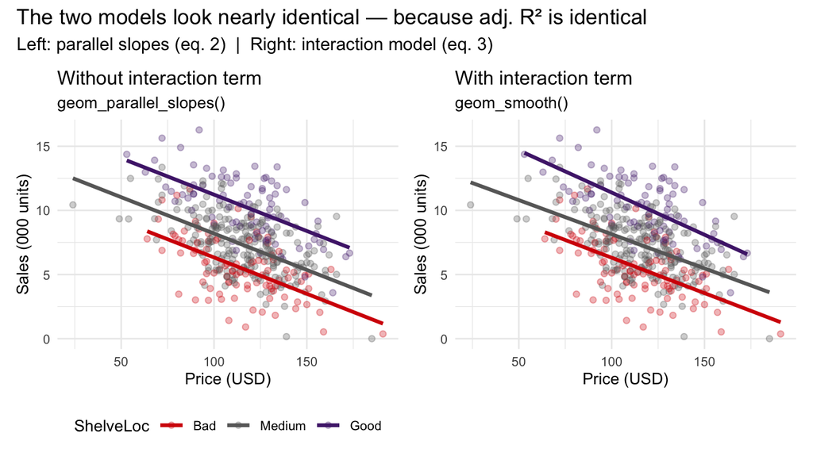

```r
p_par <- tbl_carseats %>%
  ggplot(aes(x = Price, y = Sales, color = ShelveLoc)) +
  geom_point(alpha = 0.3, size = 1.5) +
  geom_parallel_slopes(se = FALSE, linewidth = 1.1) +
  scale_color_manual(values = col_shelf) +
  labs(title    = "Without interaction term",
       subtitle = "geom_parallel_slopes()",
       x = "Price (USD)", y = "Sales (000 units)") +
  theme_minimal(base_size = 10) +
  theme(legend.position = "bottom")

p_int <- tbl_carseats %>%
  ggplot(aes(x = Price, y = Sales, color = ShelveLoc)) +
  geom_point(alpha = 0.3, size = 1.5) +
  geom_smooth(method = "lm", se = FALSE, linewidth = 1.1) +
  scale_color_manual(values = col_shelf) +
  labs(title    = "With interaction term",
       subtitle = "geom_smooth()",
       x = "Price (USD)", y = "Sales (000 units)") +
  theme_minimal(base_size = 10) +
  theme(legend.position = "none")

(p_par + p_int) +
  plot_annotation(
    title    = "The two models look nearly identical — because adj. R² is identical",
    subtitle = "Left: parallel slopes (eq. 2)  |  Right: interaction model (eq. 3)"
  )
```

### 3.7 The parallel slopes model: interpret and verify

The model is already fitted above. Here we spell out what each coefficient means and verify that the predictions match the observed group means.

**What each coefficient means:**

[output not shown]

**Verify: predicted means match observed means**

```r
b_s <- coef(mod_shelf)
mp  <- mean(tbl_carseats$Price)

cat("Predicted Sales at mean Price (", round(mp, 1), " USD):\n")
```

```
Predicted Sales at mean Price ( 115.8  USD):
```

```r
cat("  Bad:   ", round(b_s[1] + b_s[2] * mp, 2), "\n")
```

```
  Bad:    5.44
```

```r
cat("  Good:  ", round(b_s[1] + b_s[2] * mp + b_s[3], 2), "\n")
```

[output not shown]

```r
cat("  Medium:", round(b_s[1] + b_s[2] * mp + b_s[4], 2), "\n\n")
```

[output not shown]

```r
cat("Observed mean Sales:\n")
```

```
Observed mean Sales:
```

```r
tbl_carseats %>%
  group_by(ShelveLoc) %>%
  summarise(mean_sales = round(mean(Sales), 2)) %>%
  print()
```

```
# A tibble: 3 × 2
  ShelveLoc mean_sales
  <fct>          <dbl>
1 Bad             5.52
2 Medium          7.31
3 Good           10.2
```

The Carseats data give a clear verdict: parallel slopes. But the same procedure on a different dataset can yield the opposite answer. The background box below shows exactly that case.

**CautionBackground: When interaction IS warranted — UT Austin (moderndive Ch. 6)**

The moderndive textbook (`evals` dataset, $n = 463$) shows the opposite case: here the interaction *is* justified.

```r
evals_ch6 <- evals %>% select(score, age, gender)

mod_ut_par <- lm(score ~ age + gender,  data = evals_ch6)
mod_ut_int <- lm(score ~ age * gender,  data = evals_ch6)

bind_rows(
  get_regression_summaries(mod_ut_par) %>%
    mutate(Model = "Parallel slopes: score ~ age + gender", k = 3),
  get_regression_summaries(mod_ut_int) %>%
    mutate(Model = "Interaction:     score ~ age × gender", k = 4)
) %>%
  select(Model, k, r_squared, adj_r_squared, rmse) %>%
  gt() %>%
  fmt_number(columns = c(r_squared, adj_r_squared, rmse), decimals = 3) %>%
  tab_style(style = cell_fill(color = "#f0fff0"),
            locations = cells_body(rows = 2)) %>%
  tab_options(table.font.size = "13px") %>%
  tab_header("UT Austin: interaction IS warranted",
             subtitle = "adj. R² rises 0.035 → 0.045 (+29% relative) with 1 extra parameter")
```

UT Austin: interaction IS warranted

adj. R² rises 0.035 → 0.045 (+29% relative) with 1 extra parameter

| Model | k | r_squared | adj_r_squared | rmse |
| --- | --- | --- | --- | --- |
| Parallel slopes: score ~ age + gender | 3 | 0.039 | 0.035 | 0.533 |
| Interaction: score ~ age × gender | 4 | 0.051 | 0.045 | 0.529 |

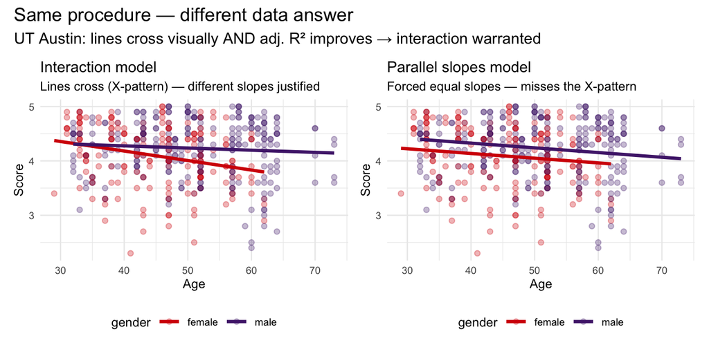

```r
p_ut_int <- evals_ch6 %>%
  ggplot(aes(x = age, y = score, color = gender)) +
  geom_point(alpha = 0.3, size = 1.5) +
  geom_smooth(method = "lm", se = FALSE, linewidth = 1.1) +
  scale_color_manual(values = c("female" = "#D50006", "male" = "#502479")) +
  labs(title = "Interaction model",
       subtitle = "Lines cross (X-pattern) — different slopes justified",
       x = "Age", y = "Score") +
  theme_minimal(base_size = 9) + theme(legend.position = "bottom")

p_ut_par <- evals_ch6 %>%
  ggplot(aes(x = age, y = score, color = gender)) +
  geom_point(alpha = 0.3, size = 1.5) +
  geom_parallel_slopes(se = FALSE, linewidth = 1.1) +
  scale_color_manual(values = c("female" = "#D50006", "male" = "#502479")) +
  labs(title = "Parallel slopes model",
       subtitle = "Forced equal slopes — misses the X-pattern",
       x = "Age", y = "Score") +
  theme_minimal(base_size = 9) + theme(legend.position = "bottom")

(p_ut_int + p_ut_par) +
  plot_annotation(
    title    = "Same procedure — different data answer",
    subtitle = "UT Austin: lines cross visually AND adj. R² improves → interaction warranted"
  )
```

|  | Carseats (ShelveLoc) | UT Austin (gender) |
| --- | --- | --- |
| Visual | Nearly parallel | Clear X-pattern |
| adj. R² gain | 0.000 | +0.010 (+29% rel.) |
| **Verdict** | **Parallel slopes** | **Interaction** |

**The procedure is identical — the data decide.**

### 3.8 ShelveLoc as a confounding variable

**Tip Instructor note — confounding**

*“`ShelveLoc` is a **confounding variable**: it correlates with Price (prime shelf locations support higher prices) AND with Sales (better placement drives more units). Without it in the model, the Price coefficient was biased — **Omitted Variable Bias**.”*

*“Adding `ShelveLoc` as a **control variable** lets us read the Price effect within comparable stores (same shelf location). That is ceteris paribus — and it is why the Price coefficient changes when we add ShelveLoc. We will quantify this in the Model Quality section.”*

## 4 Case B: Adding a Second Numeric Regressor: `Advertising`

This section covers **Case B** from the overview table: two numeric regressors (`Price` and `Advertising`). The key difference from Case A: with two numeric variables, OLS no longer fits a line — it fits a **plane** in three-dimensional space, and the ceteris-paribus interpretation becomes directly visible in the geometry.

### 4.1 From parallel lines to a plane in 3D

```r
price_grid <- seq(min(tbl_carseats$Price),       max(tbl_carseats$Price),       length.out = 30)
adv_grid   <- seq(min(tbl_carseats$Advertising), max(tbl_carseats$Advertising), length.out = 30)

# plotly add_surface expects z[i,j] = f(y_grid[i], x_grid[j])
# outer() produces z[i,j] = f(x_grid[i], y_grid[j]) → transpose needed
z_mat <- outer(price_grid, adv_grid,
               function(p, a) coef(mod_adv)[1] +
                               coef(mod_adv)[2] * p +
                               coef(mod_adv)[3] * a)

plot_ly() %>%
  add_trace(
    data   = tbl_carseats,
    x = ~Price, y = ~Advertising, z = ~Sales,
    type = "scatter3d", mode = "markers",
    marker = list(size = 3, color = "#7d0a52", opacity = 0.6),
    name = "Stores"
  ) %>%
  add_surface(
    x = price_grid, y = adv_grid, z = t(z_mat),
    colorscale = list(c(0,"#f5f0fa"), c(0.5,"#7d0a52"), c(1,"#502479")),
    opacity = 0.55, showscale = FALSE,
    name = "Regression plane"
  ) %>%
  layout(
    title = list(
      text = "Sales ~ Price + Advertising: the regression plane",
      font = list(size = 13)
    ),
    scene = list(
      xaxis  = list(title = "Price (USD)"),
      yaxis  = list(title = "Advertising (USD 000)"),
      zaxis  = list(title = "Sales (000 units)"),
      camera = list(eye = list(x = 1.8, y = -1.5, z = 0.9))
    )
  )
```

[interactive chart not shown]

**NoteWhat the 3D plot shows**

**Simple regression** ($k=1$): OLS fits a **line** — residual = vertical distance to line.

**Two numeric regressors** ($k=2$): OLS fits a **plane** — residual = vertical distance to plane.

**Partial effect from geometry:** $b_1$ is the slope of the plane *along the Price axis* while the Advertising axis is held fixed. Tilt the plot — that is ceteris paribus made visible.

**Adding ShelveLoc** (categorical): instead of one plane, OLS fits **parallel planes** (one per group, same slope) — exactly what we just estimated. With an interaction term, the planes would be **tilted** relative to each other.

**$k > 2$ regressors:** geometrically unplottable, but $\mathbf{b} = (\mathbf{X}'\mathbf{X})^{-1}\mathbf{X}'\mathbf{y}$ and the partial-derivative interpretation remain identical.

### 4.2 Fit and interpret

```r
tb <- mod_adv %>%
  get_regression_table() %>%
  select(term, estimate) %>%
  gt()
```

**Show code: table formatting**

```r
tb %>%
  fmt_number(columns = estimate, decimals = 4) %>%
  tab_style(style = cell_fill(color = "#f0fff8"),
            locations = cells_body(rows = term == "Advertising")) %>%
  tab_style(style = cell_fill(color = "#fff0f0"),
            locations = cells_body(rows = term == "Price")) %>%
  tab_options(table.font.size = "13px") %>%
  tab_header(paste0("Sales ~ Price + Advertising  |  R² = ",
                    round(summary(mod_adv)$r.squared, 3),
                    "  |  adj. R² = ",
                    round(summary(mod_adv)$adj.r.squared, 3)))
```

Sales ~ Price + Advertising | R² = 0.282 | adj. R² = 0.278

| term | estimate |
| --- | --- |
| intercept | 13.0030 |
| Price | −0.0550 |
| Advertising | 0.1230 |

### 4.3 Centering: making the intercept meaningful

$b_0 = $ 13 is the predicted Sales when Price = 0 *and* Advertising = 0 — both outside the observed range. **Mean centering** replaces $x_j$ with $x_j^c = x_j - \bar{x}_j$: then $b_0^c$ is the predicted Sales for a store with **average Price and average Advertising** — a meaningful quantity.

```r
tbl_c <- tbl_carseats %>%
  mutate(Price_c       = Price       - mean(Price),
         Advertising_c = Advertising - mean(Advertising))

mod_adv_c <- lm(Sales ~ Price_c + Advertising_c, data = tbl_c)

tb <- bind_rows(
  tidy(mod_adv)   %>% mutate(Model = "Original"),
  tidy(mod_adv_c) %>% mutate(Model = "Mean-centred")
) %>%
  select(Model, term, estimate) %>%
  pivot_wider(names_from = Model, values_from = estimate) %>%
  gt()
```

**Show code: table formatting**

```r
tb %>%
  fmt_number(columns = c(Original, `Mean-centred`), decimals = 4) %>%
  tab_options(table.font.size = "13px") %>%
  tab_header(
    "Centering: intercept changes, slopes unchanged",
    subtitle = paste0(
      "Centred intercept = predicted Sales at mean Price (",
      round(mean(tbl_carseats$Price), 1), " USD) and mean Advertising (",
      round(mean(tbl_carseats$Advertising), 1), " USD 000)")
  )
```

Centering: intercept changes, slopes unchanged

Centred intercept = predicted Sales at mean Price (115.8 USD) and mean Advertising (6.6 USD 000)

| term | Original | Mean-centred |
| --- | --- | --- |
| (Intercept) | 13.0034 | 7.4963 |
| Price | −0.0546 | NA |
| Advertising | 0.1231 | NA |
| Price_c | NA | −0.0546 |
| Advertising_c | NA | 0.1231 |

**NoteWhat centering does and does not change**

**Changes:** $b_0^c$ is now the predicted outcome at the mean of all regressors — a meaningful number: *“A store with average price and average advertising is expected to sell 7.5 thousand units.”*

**Does not change:** slopes $b_1, b_2$, R², residuals, fitted values. Centering is a reparametrisation, not a different model. Use it whenever $x = 0$ is not in the observed range.

### 4.4 Simpson’s Paradox — when aggregate trends mislead

Adding a second numeric regressor can reverse the sign of a coefficient. This is Simpson’s Paradox: a trend visible in the aggregate disappears or reverses when a third variable is controlled for.

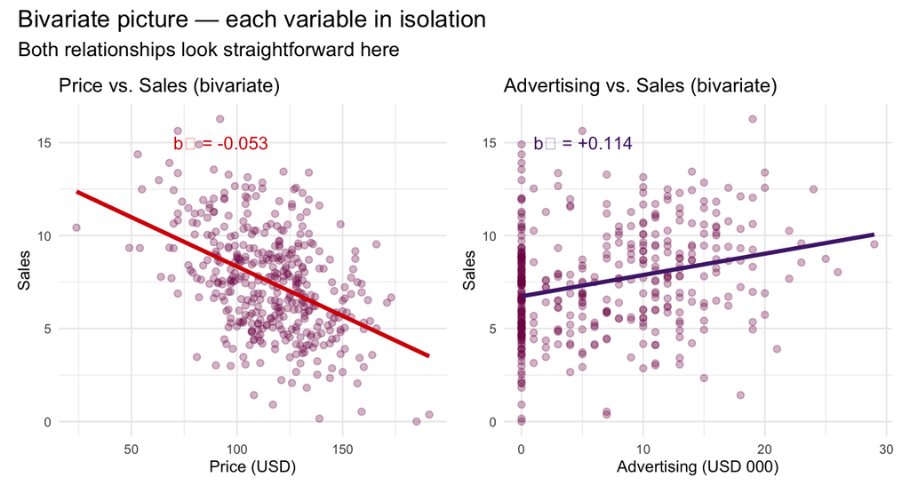

```r
# Simple bivariate plots
p_price <- tbl_carseats %>%
  ggplot(aes(x = Price, y = Sales)) +
  geom_point(alpha = 0.3, color = "#7d0a52", size = 1.5) +
  geom_smooth(method = "lm", se = FALSE, color = "#D50006", linewidth = 1.1) +
  annotate("text", x = 70, y = 15,
           label = paste0("b₁ = ", round(coef(mod_baseline)["Price"], 3)),
           color = "#D50006", size = 3.5, hjust = 0) +
  labs(title = "Price vs. Sales (bivariate)",
       x = "Price (USD)", y = "Sales") +
  theme_minimal(base_size = 9)

p_adv_simple <- tbl_carseats %>%
  ggplot(aes(x = Advertising, y = Sales)) +
  geom_point(alpha = 0.3, color = "#7d0a52", size = 1.5) +
  geom_smooth(method = "lm", se = FALSE, color = "#502479", linewidth = 1.1) +
  annotate("text", x = 1, y = 15,
           label = paste0("b₁ = +", round(coef(lm(Sales~Advertising,tbl_carseats))["Advertising"], 3)),
           color = "#502479", size = 3.5, hjust = 0) +
  labs(title = "Advertising vs. Sales (bivariate)",
       x = "Advertising (USD 000)", y = "Sales") +
  theme_minimal(base_size = 9)

(p_price + p_adv_simple) +
  plot_annotation(
    title    = "Bivariate picture — each variable in isolation",
    subtitle = "Both relationships look straightforward here"
  )
```

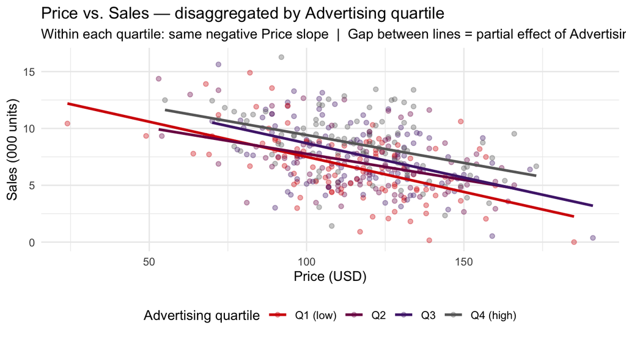

```r
# ntile() avoids non-unique breaks caused by Advertising's many zero values
tbl_carseats %>%
  mutate(adv_q = factor(ntile(Advertising, 4),
                        labels = c("Q1 (low)", "Q2", "Q3", "Q4 (high)"))) %>%
  ggplot(aes(x = Price, y = Sales, color = adv_q)) +
  geom_point(alpha = 0.35, size = 1.5) +
  geom_smooth(method = "lm", se = FALSE, linewidth = 1.0) +
  scale_color_manual(values = c("Q1 (low)" = "#D50006",
                                "Q2"       = "#7d0a52",
                                "Q3"       = "#502479",
                                "Q4 (high)"= "#686868")) +
  labs(
    title    = "Price vs. Sales — disaggregated by Advertising quartile",
    subtitle = paste0(
      "Within each quartile: same negative Price slope  |  ",
      "Gap between lines = partial effect of Advertising  |  ",
      "Parallel ≈ no interaction (confirms adj. R² finding)"),
    x = "Price (USD)", y = "Sales (000 units)",
    color = "Advertising quartile"
  ) +
  theme_minimal(base_size = 11) +
  theme(legend.position = "bottom")
```

**NoteSimpson’s Paradox in the multiple regression context**

When two regressors are correlated, the bivariate slope of one variable can differ substantially from its partial slope in the multiple model.

**In Carseats:** Price and Advertising are only weakly correlated (0.045), so the sign reversal that characterises strong Simpson cases does not occur here. The slopes within each Advertising quartile are nearly parallel — confirming the parallel-slopes model and the absence of a meaningful interaction.

**The classic Simpson case** (moderndive Ch. 6, Credit data): Income has a *positive* bivariate relationship with credit card debt, but a *negative* partial slope once credit limit is controlled for — a full sign reversal caused by a strong confounder. The background box below shows the full story.